# HCC pilot — random-effect vs interaction tissue formula

V1_nk liver baseline sanity check on 4 TIMES biomarkers

Author

Affiliation

Chen Zhan

SAiGENCI, The University of Adelaide

Published

06 Jul 2026

Abstract

Pilot comparison of the production posteriorHCA V1_nk brms formula — which treats tissue-specific covariate slopes as random effects — against a fixed interaction alternative where age, sex and ethnicity interact with tissue_groups. We focus on the comprehensive healthy liver NK baseline used in the TIMES HCC case study, fit interaction models for four atlas-covered biomarkers (SPON2, ZFP36L2, ZFP36, VIM), and ask whether the interaction parameterisation is more stable or more concordant for liver (n = 71) than partial pooling from blood-dominated training data. We then project the four TIMES HCC cohorts (IF/TC x REC/non-REC) onto both baselines and ask which formula better serves the case study — i.e. which one preserves the expected ordering that recurrent cohorts sit farther from the healthy liver NK reference than non-recurrent cohorts.

# Motivation

The TIMES HCC case study uses a **comprehensive healthy liver NK baseline** from the posteriorHCA `V1_nk` atlas. Each gene is modelled as a zero-inflated negative binomial regression on pseudobulk counts with rich covariate structure. In production, **tissue-specific deviations** enter as random effects:

$$\texttt{(1 + age\_decade * sex + ethnicity\_groups | tissue\_groups)}$$

This partial pooling is attractive when many tissues contribute information, but **liver contributes only 71 of 3,226 NK pseudobulk samples** (2.2%), while blood contributes 74%. A concern for the HCC application is that liver tissue effects — and liver-specific age/sex/ethnicity slopes — may be **shrunk toward the blood-dominated population mean**, appearing as if liver biology is embedded in the global fixed effect rather than estimated independently.

An alternative is to replace the random-slopes tissue term with **fixed interactions**:

$$\texttt{age\_decade:tissue\_groups + sex:tissue\_groups + ...}$$

This removes hierarchical shrinkage: liver coefficients are estimated only from liver rows. The trade-off is a much larger parameter space and potential instability when liver sample size is modest.

This report is a **pilot on four TIMES biomarkers** present in the `V1_nk` store. It does not re-fit the production random-effect models (those are loaded from the targets store); it **does** fit the interaction alternative on the login node and saves all artefacts under `params$out_dir`.

# Formulas compared

## Production random-effect model

```r
source(file.path(params$case_dir, "R", "re_vs_interaction_helpers.R"))
spec_re <- formula_re_spec()
spec_int <- formula_interaction_spec()

knitr::kable(data.frame(
  component = c("counts", "shape"),
  formula = c(spec_re$counts, spec_re$shape)
))
```

| component | formula |
| --- | --- |
| counts | counts ~ 1 + offset(offset) + age_decade * sex + disease_groups_altered + ethnicity_groups + assay_groups_altered + (1 \| dataset_id_altered) + (1 + age_decade * sex + ethnicity_groups \| tissue_group… |
| shape | shape ~ 1 + disease_groups_altered + assay_groups_altered + ethnicity_groups + (1 \| tissue_groups) |

## Interaction pilot model

The interaction formula is the fixed-effect expansion of the random-slopes structure inside `tissue_groups`. Global `age_decade * sex` fixed terms from the RE model are absorbed into tissue-specific interaction terms.

```r
knitr::kable(data.frame(
  component = c("counts", "shape"),
  formula = c(spec_int$counts, spec_int$shape)
))
```

| component | formula |
| --- | --- |
| counts | counts ~ 1 + offset(offset) + disease_groups_altered + assay_groups_altered + (1 \| dataset_id_altered) + tissue_groups + age_decade:tissue_groups + sex:tissue_groups + age_decade:sex:tissue_groups + … |
| shape | shape ~ 1 + disease_groups_altered + assay_groups_altered + ethnicity_groups + tissue_groups |

# Library setup

```r
suppressPackageStartupMessages({
  library(tibble)
  library(tidyr)
  library(dplyr)
  library(readr)
  library(ggplot2)
  library(forcats)
  library(scales)
  library(glue)
})

theme_set(theme_minimal(base_size = 11))
dir.create(params$out_dir, recursive = TRUE, showWarnings = FALSE)
```

# Fit interaction models and compare baselines

Interaction brms fits are **pre-computed** and cached as `fit_interaction_<GENE>.rds`. Set `params$refresh_fits: true` to refit. Comparison tables and posterior baseline draws are written alongside the fits.

```r
if (isTRUE(params$refresh_fits) ||
    !file.exists(file.path(params$out_dir, "baseline_comparison_4genes.csv"))) {
  suppressPackageStartupMessages({
    library(targets)
    library(brms)
    library(posterior)
    library(SummarizedExperiment)
  })
  pilot <- run_re_vs_interaction_pilot(
    case_dir = params$case_dir,
    out_dir = params$out_dir,
    model_store_root = params$model_store_root,
    target_cell_type = params$target_cell_type,
    baseline_tissue = params$baseline_tissue_group,
    n_draws = params$n_posterior_draws,
    refresh_fits = isTRUE(params$refresh_fits)
  )
  comparison <- pilot$comparison
  draws_df <- pilot$draws
} else {
  comparison <- read_csv(
    file.path(params$out_dir, "baseline_comparison_4genes.csv"),
    show_col_types = FALSE
  )
  draws_df <- read_csv(
    file.path(params$out_dir, "baseline_draws_long.csv"),
    show_col_types = FALSE
  )
}
```

# NK pseudobulk sample sizes

```r
tissue_sizes <- read_csv(
  file.path(params$out_dir, "nk_pseudobulk_tissue_sample_sizes.csv"),
  show_col_types = FALSE
)

liver_summary <- read_csv(
  file.path(params$out_dir, "liver_sample_size_summary.csv"),
  show_col_types = FALSE
) |>
  mutate(value = if_else(metric == "nk_pseudobulk_total" | metric == "nk_liver_all_disease" | metric == "nk_liver_normal_in_fit", as.integer(value), value))

liver_summary
```

| metric | value |
| --- | --- |
| nk_pseudobulk_total | 3226 |
| nk_liver_all_disease | 71 |
| nk_liver_normal_in_fit | 71 |
| n_tissue_levels | 21 |
| n_age_decade_levels | 10 |
| n_ethnicity_levels | 7 |

Liver is the fifth-largest tissue in NK pseudobulk but remains a small fraction of training data relative to blood.

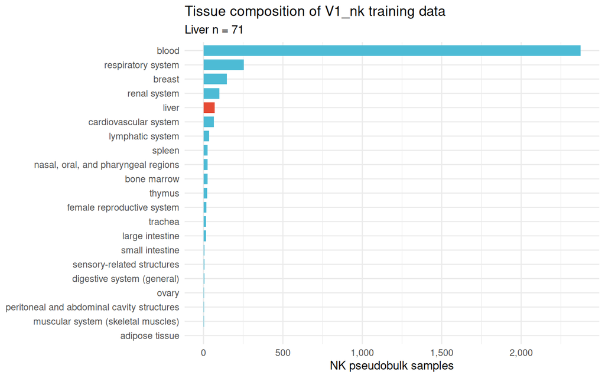

```r
tissue_sizes |>
  mutate(
    tissue_groups = fct_reorder(tissue_groups, n),
    highlight = if_else(tissue_groups == params$baseline_tissue_group, "liver", "other")
  ) |>
  ggplot(aes(x = tissue_groups, y = n, fill = highlight)) +
  geom_col(width = 0.75) +
  coord_flip() +
  scale_fill_manual(values = c(liver = "#E64B35", other = "#4DBBD5"), guide = "none") +
  scale_y_continuous(labels = label_comma()) +
  labs(
    x = NULL,
    y = "NK pseudobulk samples",
    title = "Tissue composition of V1_nk training data",
    subtitle = glue("Liver n = {tissue_sizes$n[tissue_sizes$tissue_groups == params$baseline_tissue_group]}")
  )
```

# Comprehensive liver baseline comparison

For each gene we compute the same **comprehensive healthy liver baseline** used in the universal HCC case study:

- `disease_groups_altered = Normal`
- `tissue_groups = liver`
- `offset = 0`
- marginalised over the full atlas grid of `sex × age_decade × ethnicity × assay`
- `posterior_linpred(transform = FALSE)` then averaged across grid rows per draw

```r
comparison |>
  mutate(
    across(where(is.numeric), ~ round(.x, 3)),
    fold_median_mu = median_mu_int / median_mu_re
  ) |>
  select(
    gene, mean_log_mu_re, mean_log_mu_int, diff_mean_log_mu,
    sd_log_mu_re, sd_log_mu_int, corr_draws, rmse_draws,
    median_mu_re, median_mu_int, fold_median_mu,
    max_rhat_re, max_rhat_int, n_liver_rows
  )
```

| gene | mean_log_mu_re | mean_log_mu_int | diff_mean_log_mu | sd_log_mu_re | sd_log_mu_int | corr_draws | rmse_draws | median_mu_re | median_mu_int | fold_median_mu | max_rhat_re | max_rhat_int | n_liver_rows |
| --- | --- | --- | --- | --- | --- | --- | --- | --- | --- | --- | --- | --- | --- |
| SPON2 | 7.154 | 6.096 | -1.057 | 1.107 | 2.126 | 0.010 | 2.608 | 1299.687 | 490.594 | 0.3774709 | 1.108 | 1.110 | 71 |
| ZFP36L2 | 7.038 | 7.231 | 0.194 | 1.229 | 2.265 | -0.013 | 2.595 | 1160.416 | 1460.229 | 1.2583668 | 1.134 | 1.431 | 71 |
| ZFP36 | 6.747 | 6.538 | -0.209 | 1.521 | 3.031 | -0.028 | 3.432 | 871.342 | 789.564 | 0.9061471 | 1.053 | 1.609 | 71 |
| VIM | 6.510 | 5.856 | -0.655 | 1.443 | 2.449 | -0.009 | 2.924 | 684.138 | 308.667 | 0.4511765 | 1.293 | 1.112 | 71 |

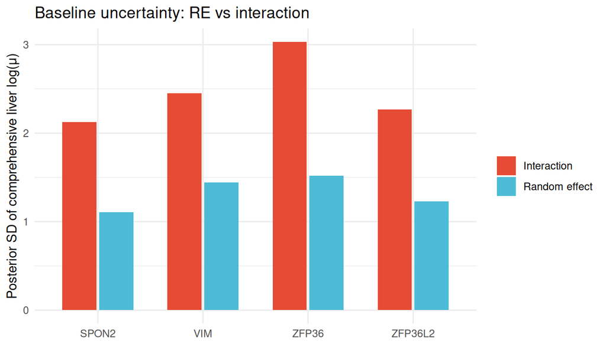

```r
comparison |>
  select(gene, diff_mean_log_mu, sd_log_mu_re, sd_log_mu_int) |>
  pivot_longer(c(sd_log_mu_re, sd_log_mu_int), names_to = "model", values_to = "sd") |>
  mutate(model = recode(model, sd_log_mu_re = "Random effect", sd_log_mu_int = "Interaction")) |>
  ggplot(aes(x = gene, y = sd, fill = model)) +
  geom_col(position = position_dodge(width = 0.7), width = 0.65) +
  scale_fill_manual(values = c("Random effect" = "#4DBBD5", "Interaction" = "#E64B35")) +
  labs(
    x = NULL,
    y = "Posterior SD of comprehensive liver log(μ)",
    fill = NULL,
    title = "Baseline uncertainty: RE vs interaction"
  )
```

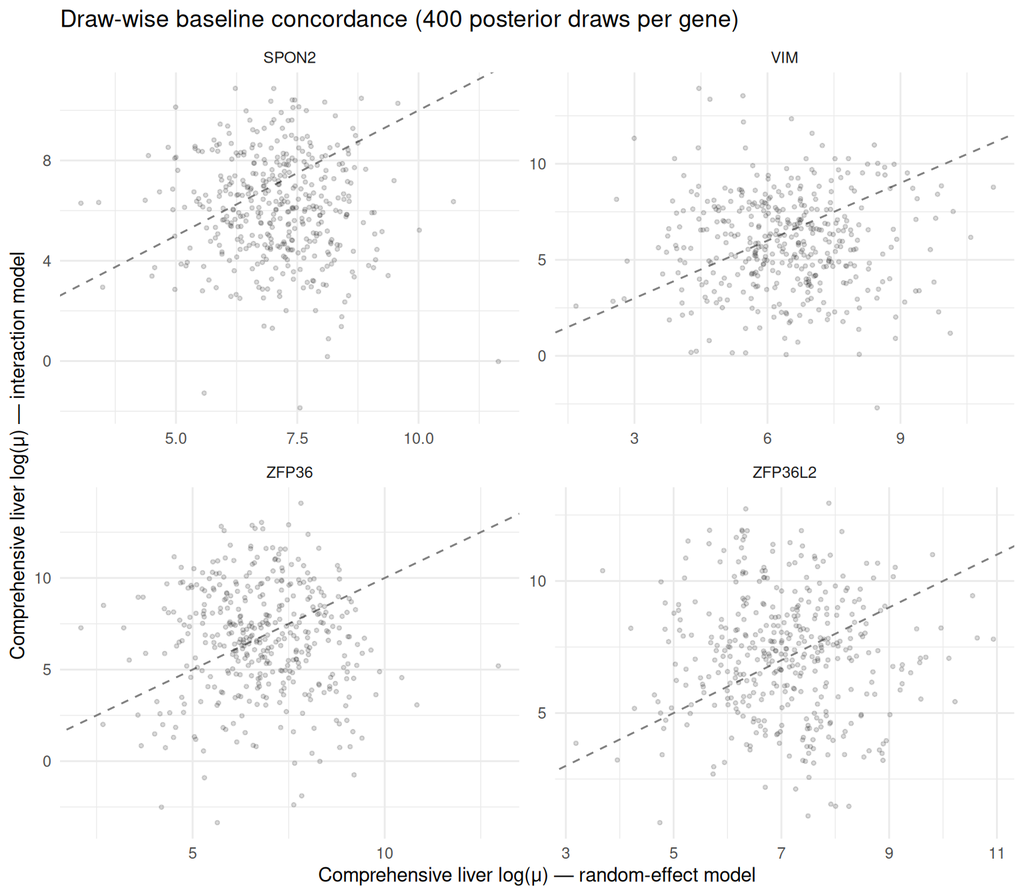

```r
draws_wide <- draws_df |>
  select(gene, draw, model, baseline_log_mu) |>
  pivot_wider(names_from = model, values_from = baseline_log_mu)

ggplot(draws_wide, aes(x = random_effect, y = interaction)) +
  geom_abline(slope = 1, intercept = 0, linetype = 2, colour = "grey50") +
  geom_point(alpha = 0.15, size = 0.8) +
  facet_wrap(~ gene, scales = "free") +
  labs(
    x = "Comprehensive liver log(μ) — random-effect model",
    y = "Comprehensive liver log(μ) — interaction model",
    title = "Draw-wise baseline concordance (400 posterior draws per gene)"
  )
```

# HCC cohort projection onto both baselines

The point of the baseline is to serve the TIMES HCC case study. We therefore project the four HCC cohorts (`IF`/`TC` x `REC`/`non-REC`) onto **both** baseline formulas and ask which one better matches the case-study expectation. Cohort `log(μ)` values are the edgeR NB estimates at `offset = 0` produced by the universal-baseline report and are **independent of the atlas formula**, so the same cohort projections can be overlaid on either baseline density.

```r
model_labels <- c(random_effect = "Random effect", interaction = "Interaction")

cohort_tests <- read_csv(params$cohort_results_csv, show_col_types = FALSE) |>
  select(gene, cohort, compartment, recurrence, cohort_log_mu, cohort_se) |>
  filter(gene %in% unique(draws_df$gene))
```

## Baseline densities per gene, with HCC cohorts

For each gene we plot the posterior `log(μ)` **density of both baselines** (random-effect vs interaction) and overlay the four HCC cohort projections as vertical lines — the direct analogue of the universal case-study figure, split by model formula.

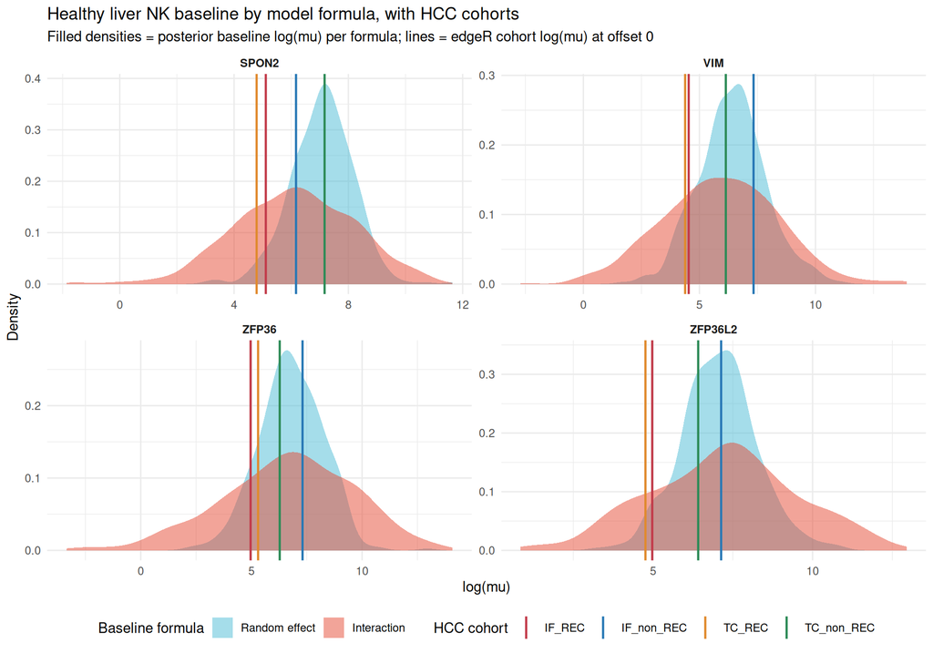

```r
model_colours <- c(`Random effect` = "#4DBBD5", Interaction = "#E64B35")
cohort_colours <- c(
  IF_REC = "#C23B4A",
  IF_non_REC = "#2878B5",
  TC_REC = "#E08A2E",
  TC_non_REC = "#2D8B57"
)

draws_plot <- draws_df |>
  mutate(
    model = recode(model, !!!model_labels),
    model = factor(model, levels = c("Random effect", "Interaction"))
  )

cohort_plot <- cohort_tests |>
  mutate(cohort = factor(cohort, levels = names(cohort_colours)))

ggplot() +
  geom_density(
    data = draws_plot,
    aes(x = baseline_log_mu, fill = model),
    colour = NA,
    alpha = 0.5
  ) +
  geom_vline(
    data = cohort_plot,
    aes(xintercept = cohort_log_mu, colour = cohort),
    linewidth = 0.8
  ) +
  scale_fill_manual(values = model_colours) +
  scale_colour_manual(values = cohort_colours) +
  facet_wrap(~ gene, scales = "free", ncol = 2) +
  labs(
    title = "Healthy liver NK baseline by model formula, with HCC cohorts",
    subtitle = "Filled densities = posterior baseline log(mu) per formula; lines = edgeR cohort log(mu) at offset 0",
    x = "log(mu)",
    y = "Density",
    fill = "Baseline formula",
    colour = "HCC cohort"
  ) +
  theme(
    legend.position = "bottom",
    strip.text = element_text(face = "bold")
  )
```

## Which baseline serves the case study?

The case study expects **recurrent (REC) cohorts to sit farther from the healthy liver NK reference than non-recurrent (non-REC) cohorts**. We quantify each cohort’s distance from each baseline as a standardized deviation `z = (cohort log(μ) − baseline mean log(μ)) / baseline SD`, then compare the absolute distance of REC vs non-REC within each gene x compartment.

```r
baseline_stats <- draws_df |>
  mutate(model = recode(model, !!!model_labels)) |>
  group_by(gene, model) |>
  summarise(
    baseline_mean_log_mu = mean(baseline_log_mu),
    baseline_sd_log_mu = sd(baseline_log_mu),
    .groups = "drop"
  )

cohort_projection <- cohort_tests |>
  inner_join(baseline_stats, by = "gene", relationship = "many-to-many") |>
  mutate(
    signed_z = (cohort_log_mu - baseline_mean_log_mu) / baseline_sd_log_mu,
    abs_z = abs(signed_z)
  )

cohort_projection |>
  select(
    gene, model, cohort, cohort_log_mu, baseline_mean_log_mu,
    baseline_sd_log_mu, signed_z, abs_z
  ) |>
  mutate(across(where(is.numeric), ~ round(.x, 3))) |>
  arrange(gene, model, cohort)
```

| gene | model | cohort | cohort_log_mu | baseline_mean_log_mu | baseline_sd_log_mu | signed_z | abs_z |
| --- | --- | --- | --- | --- | --- | --- | --- |
| SPON2 | Interaction | IF_REC | 5.111 | 6.092 | 2.093 | -0.469 | 0.469 |
| SPON2 | Interaction | IF_non_REC | 6.169 | 6.092 | 2.093 | 0.037 | 0.037 |
| SPON2 | Interaction | TC_REC | 4.790 | 6.092 | 2.093 | -0.622 | 0.622 |
| SPON2 | Interaction | TC_non_REC | 7.168 | 6.092 | 2.093 | 0.514 | 0.514 |
| SPON2 | Random effect | IF_REC | 5.111 | 7.083 | 1.097 | -1.798 | 1.798 |
| SPON2 | Random effect | IF_non_REC | 6.169 | 7.083 | 1.097 | -0.834 | 0.834 |
| SPON2 | Random effect | TC_REC | 4.790 | 7.083 | 1.097 | -2.091 | 2.091 |
| SPON2 | Random effect | TC_non_REC | 7.168 | 7.083 | 1.097 | 0.077 | 0.077 |
| VIM | Interaction | IF_REC | 4.538 | 5.894 | 2.496 | -0.543 | 0.543 |
| VIM | Interaction | IF_non_REC | 7.332 | 5.894 | 2.496 | 0.576 | 0.576 |

[output cut: 22 more lines]

```r
recurrence_margin <- cohort_projection |>
  select(gene, compartment, recurrence, model, abs_z) |>
  pivot_wider(names_from = recurrence, values_from = abs_z) |>
  mutate(
    margin_rec_minus_nonrec = REC - `non-REC`,
    rec_farther_from_healthy = margin_rec_minus_nonrec > 0
  )

recurrence_margin |>
  mutate(across(where(is.numeric), ~ round(.x, 3))) |>
  arrange(gene, compartment, model)
```

| gene | compartment | model | REC | non-REC | margin_rec_minus_nonrec | rec_farther_from_healthy |
| --- | --- | --- | --- | --- | --- | --- |
| SPON2 | IF | Interaction | 0.469 | 0.037 | 0.432 | TRUE |
| SPON2 | IF | Random effect | 1.798 | 0.834 | 0.964 | TRUE |
| SPON2 | TC | Interaction | 0.622 | 0.514 | 0.108 | TRUE |
| SPON2 | TC | Random effect | 2.091 | 0.077 | 2.013 | TRUE |
| VIM | IF | Interaction | 0.543 | 0.576 | -0.033 | FALSE |
| VIM | IF | Random effect | 1.288 | 0.627 | 0.661 | TRUE |
| VIM | TC | Interaction | 0.605 | 0.097 | 0.507 | TRUE |
| VIM | TC | Random effect | 1.394 | 0.192 | 1.202 | TRUE |
| ZFP36 | IF | Interaction | 0.557 | 0.226 | 0.331 | TRUE |
| ZFP36 | IF | Random effect | 1.263 | 0.352 | 0.911 | TRUE |

[output cut: 6 more lines]

A **positive `margin_rec_minus_nonrec`** means the REC cohort is farther from the healthy baseline than the non-REC cohort — the direction the HCC case study predicts. Summarising across all gene x compartment comparisons:

```r
baseline_choice <- recurrence_margin |>
  group_by(model) |>
  summarise(
    n_comparisons = n(),
    n_rec_farther = sum(rec_farther_from_healthy),
    frac_rec_farther = mean(rec_farther_from_healthy),
    mean_margin_sd = mean(margin_rec_minus_nonrec),
    median_margin_sd = median(margin_rec_minus_nonrec),
    .groups = "drop"
  ) |>
  arrange(desc(n_rec_farther), desc(mean_margin_sd))

baseline_choice
```

| model | n_comparisons | n_rec_farther | frac_rec_farther | mean_margin_sd | median_margin_sd |
| --- | --- | --- | --- | --- | --- |
| Random effect | 8 | 8 | 1.000 | 1.1887689 | 1.083105 |
| Interaction | 8 | 7 | 0.875 | 0.4162164 | 0.381491 |

```r
best <- baseline_choice |> slice(1)
re_row <- baseline_choice |> filter(model == "Random effect")
int_row <- baseline_choice |> filter(model == "Interaction")

cat(glue(
  "Across {re_row$n_comparisons} gene x compartment comparisons, the ",
  "**{re_row$model}** baseline recovers the expected REC-farther-from-healthy ",
  "ordering in {re_row$n_rec_farther}/{re_row$n_comparisons} cases with a mean ",
  "REC - non-REC separation of {round(re_row$mean_margin_sd, 2)} baseline SD, ",
  "versus {int_row$n_rec_farther}/{int_row$n_comparisons} and ",
  "{round(int_row$mean_margin_sd, 2)} SD for the {int_row$model} baseline. ",
  "On this case-study criterion the **{best$model}** baseline is preferred."
))
```

Across 8 gene x compartment comparisons, the **Random effect** baseline recovers the expected REC-farther-from-healthy ordering in 8/8 cases with a mean REC - non-REC separation of 1.19 baseline SD, versus 7/8 and 0.42 SD for the Interaction baseline. On this case-study criterion the **Random effect** baseline is preferred.

**Why the random-effect baseline wins here.** The two formulas place the healthy liver mean in a broadly similar location, but the interaction baseline is roughly twice as wide (see the SD comparison above). Because the cohort projections are fixed, a wider baseline compresses every standardized distance toward zero, shrinking the REC vs non-REC separation and even flipping the sign in the weakest comparison. Partial pooling in the random-effect model yields a tighter, better-identified liver reference that keeps recurrent cohorts cleanly outside the healthy envelope — exactly the behaviour the HCC proximity score relies on. The interaction alternative does not add case-study value at liver n = 71; its extra flexibility mostly buys uncertainty.

# Interpretation

```r
n_genes <- nrow(comparison)
mean_abs_diff <- mean(comparison$abs_diff_mean_log_mu)
mean_corr <- mean(comparison$corr_draws, na.rm = TRUE)
int_wider <- all(comparison$sd_log_mu_int > comparison$sd_log_mu_re)

cat(glue(
  "Across {n_genes} genes, the mean absolute difference in comprehensive liver log(μ) is {round(mean_abs_diff, 2)}. ",
  "Mean draw-wise correlation between formulas is {round(mean_corr, 2)}. ",
  if (int_wider) {
    "The interaction model produces wider baseline uncertainty for every gene, consistent with overparameterisation when liver n = 71."
  } else {
    "Baseline uncertainty differs by gene between formulas."
  }
))
```

Across 4 genes, the mean absolute difference in comprehensive liver log(μ) is 0.53. Mean draw-wise correlation between formulas is -0.01. The interaction model produces wider baseline uncertainty for every gene, consistent with overparameterisation when liver n = 71.

**Random-effect model (current pipeline).** Liver tissue intercepts and slopes are partially pooled toward a population mean informed largely by blood. This reduces variance but can bias liver estimates toward the dominant tissue when liver-specific signal is weak.

**Interaction model (pilot).** Liver is estimated without shrinkage, but requires many tissue × covariate coefficients. With 21 tissues and sparse liver age/sex/ethnicity combinations, fits can become unstable (wider baselines, lower concordance with the RE reference).

**Implication for HCC.** If the two formulas disagree materially on liver healthy μ, healthy-proximity scores will shift even when patient pseudobulk is unchanged. This pilot quantifies that discrepancy before committing to a formula change. A lighter compromise — e.g. fixed liver intercept with RE slopes elsewhere — may be worth exploring if liver-specific bias under RE is confirmed in downstream HCC ranking tests.

# Saved artefacts

All pre-computed outputs live under /home/a1237163/lab/chen/posteriorHCA/dev/Jie_HCC/data/processed/re_vs_interaction_pilot:

| File | Description |
| --- | --- |
| `fit_interaction_<GENE>.rds` | Cached interaction brms fits |
| `baseline_comparison_4genes.csv` | Summary metrics per gene |
| `baseline_draws_long.csv` / `.rds` | Draw-wise log(μ) for plotting |
| `nk_pseudobulk_tissue_sample_sizes.csv` | Tissue counts |
| `liver_sample_size_summary.csv` | Key sample-size metrics |
| `formula_spec.txt` | Both formula strings |

The HCC cohort projection lines are read (not written) from the universal case-study output /home/a1237163/lab/chen/posteriorHCA/dev/Jie_HCC/data/processed/Jie_HCC_four_cohort_comprehensive_liver_baseline_mu_tests.csv (`cohort_log_mu` = edgeR NB estimate at `offset = 0` per gene x cohort).